# Age Risk Correlate

Age is a potential confounder because immune markers are lower in older people and age is also associated with risk of mild-moderate-severe COVID and severe COVID in complicated ways.

### Age risk curves

#### Summary

In AZ stage 1, the risk is a step function of age with a sudden drop at around 65 in the placebo arm; in the vaccine arm, the risk drops between 50 and 65.

In NVX US stage 1, the risk shows a gradual drop as age increases in the placebo arm; in the vaccine arm, the risk is very low and mostly flat.

In NVX UK, the risk shows a gradual drop as age increases in the placebo arm; in the vaccine arm, the risk also decreases as age increases.

In NVX US stage 2, the risk of Delta COVID shows a gradual drop as age increases in the vaccine arm; the risk of severe COVID is low under 40, rises from 40 to 50 and stays elevated.

#### AZ stage 1

```
## replace the existing one.Coordinate system already present. Adding new coordinate system, which will
## replace the existing one.
```

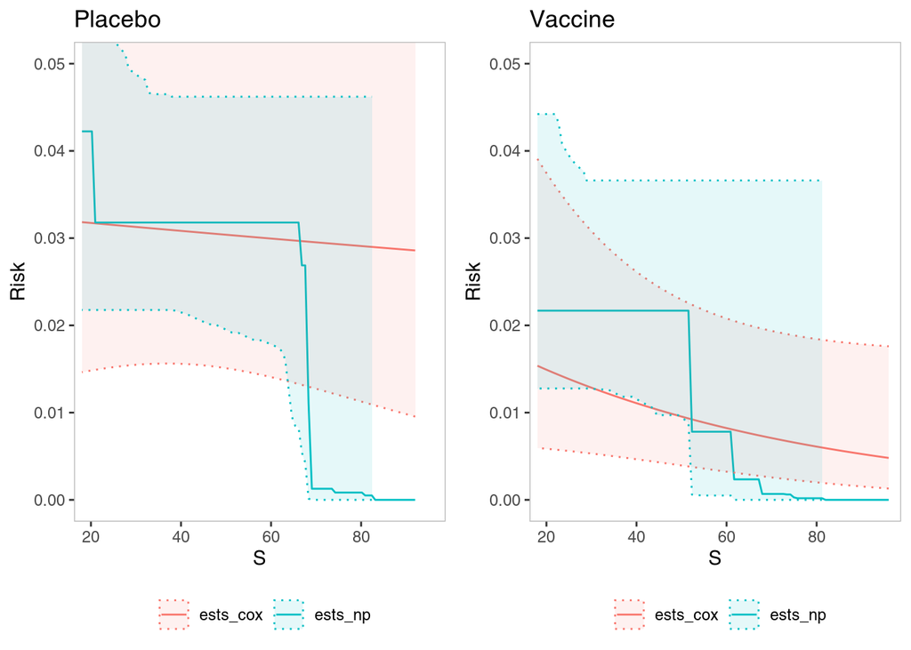

```r
load("~/correlates_reporting2/cor_coxph/output/age_risk/azd1222.stage1.Rdata")

plot_grid(
  p1=with(azd1222.stage1.plac, plot_ce(ests_cox, ests_np)) + coord_cartesian(ylim = c(0, 0.05), xlim = c(20, 95)) + ggtitle("Placebo"),
  p2=with(azd1222.stage1.vacc, plot_ce(ests_cox, ests_np)) + coord_cartesian(ylim = c(0, 0.05), xlim = c(20, 95)) + ggtitle("Vaccine"),
  ncol = 2)
```

#### NVX PREVENT19 stage 1

```
## replace the existing one.Coordinate system already present. Adding new coordinate system, which will
## replace the existing one.
```

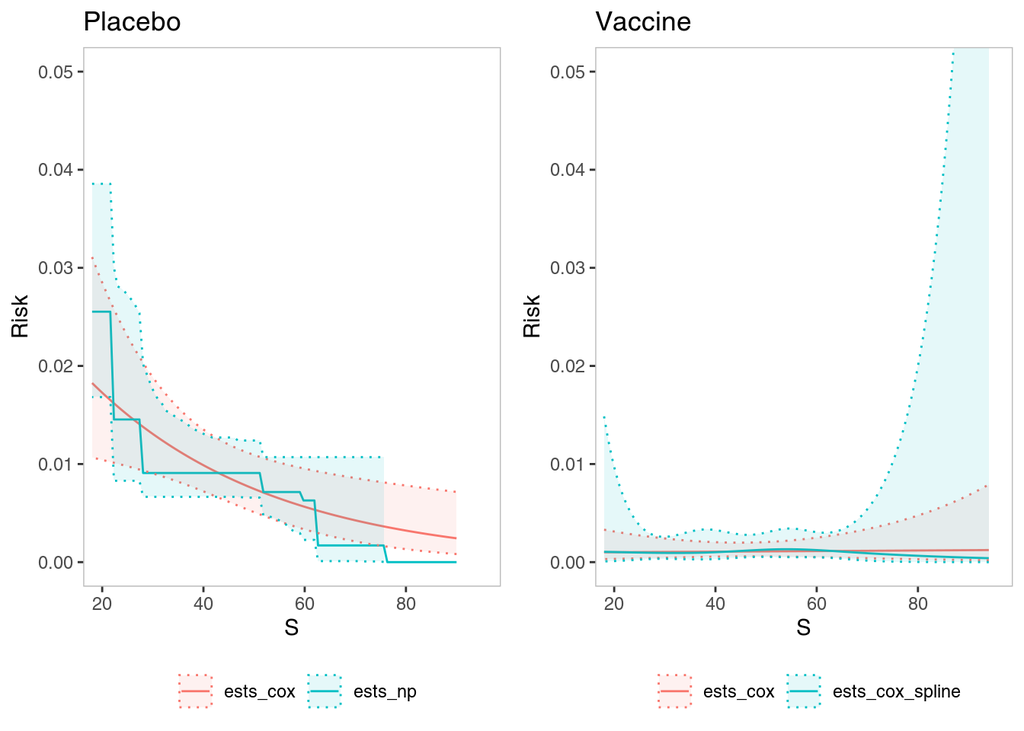

```r
load("~/correlates_reporting2/cor_coxph/output/age_risk/prevent19.stage1.Rdata")

plot_grid(
  p1=with(prevent19.stage1.plac, plot_ce(ests_cox, ests_np)) + coord_cartesian(ylim = c(0, 0.05), xlim = c(20, 95)) + ggtitle("Placebo"),
  p2=with(prevent19.stage1.vacc, plot_ce(ests_cox, ests_cox_spline)) + coord_cartesian(ylim = c(0, 0.05), xlim = c(20, 95)) + ggtitle("Vaccine"),
  ncol = 2)
```

#### NVX UK302 stage 1

```
## replace the existing one.Coordinate system already present. Adding new coordinate system, which will
## replace the existing one.
```

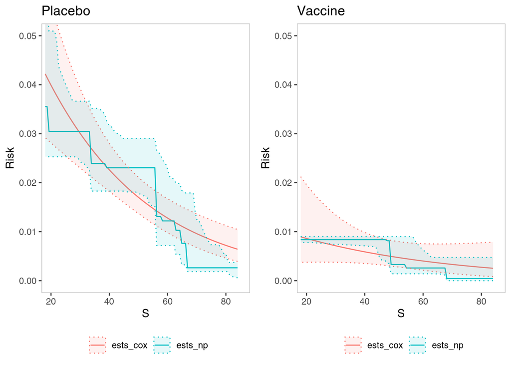

```r
load("~/correlates_reporting2/cor_coxph/output/age_risk/uk302.Rdata")

plot_grid(
  p1=with(uk302.plac, plot_ce(ests_cox, ests_np)) + coord_cartesian(ylim = c(0, 0.05), xlim = c(20, 85)) + ggtitle("Placebo"),
  p2=with(uk302.vacc, plot_ce(ests_cox, ests_np)) + coord_cartesian(ylim = c(0, 0.05), xlim = c(20, 85)) + ggtitle("Vaccine"),
  ncol = 2)
```

#### PREVENT19 stage 2

```
## replace the existing one.Coordinate system already present. Adding new coordinate system, which will
## replace the existing one.
```

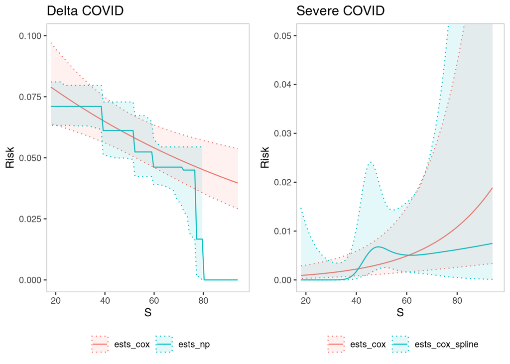

```r
load("~/correlates_reporting2/cor_coxph/output/age_risk/prevent19.stage2.Rdata")

plot_grid(
  p1=with(prevent19.stage2.delta,  plot_ce(ests_cox, ests_np)) + coord_cartesian(ylim = c(0, 0.1), xlim = c(20, 95)) + ggtitle("Delta COVID"),
  p2=with(prevent19.stage2.severe, plot_ce(ests_cox, ests_cox_spline)) + coord_cartesian(ylim = c(0, 0.05), xlim = c(20, 95)) + ggtitle("Severe COVID"),
  ncol = 2)
```

### Cox models

#### NVX PREVENT19 stage 1, placebo arm

Age (continuous) is a better predictor than age group, log likelihood ratio 1.5.

```r
coxph(Surv(EventTimePrimaryD35,EventIndPrimaryD35)~Age, subset(dat_prevent19_stage1, ph1.D35==1 & Trt==0 & Bserostatus==0 & Country==0))
```

```
## Call:
## coxph(formula = Surv(EventTimePrimaryD35, EventIndPrimaryD35) ~
##     Age, data = subset(dat_prevent19_stage1, ph1.D35 == 1 & Trt ==
##     0 & Bserostatus == 0 & Country == 0))
##
##         coef exp(coef) se(coef)      z       p
## Age -0.02787   0.97251  0.01062 -2.625 0.00867
##
## Likelihood ratio test=7.14  on 1 df, p=0.007545
## n= 6821, number of events= 43
```

```r
coxph(Surv(EventTimePrimaryD35,EventIndPrimaryD35)~Senior, subset(dat_prevent19_stage1, ph1.D35==1 & Trt==0 & Bserostatus==0 & Country==0))
```

```
## Call:
## coxph(formula = Surv(EventTimePrimaryD35, EventIndPrimaryD35) ~
##     Senior, data = subset(dat_prevent19_stage1, ph1.D35 == 1 &
##     Trt == 0 & Bserostatus == 0 & Country == 0))
##
##           coef exp(coef) se(coef)      z      p
## Senior -1.7632    0.1715   1.0120 -1.742 0.0815
##
## Likelihood ratio test=5.62  on 1 df, p=0.01771
## n= 6821, number of events= 43
```

```r
coxph(Surv(EventTimePrimaryD35,EventIndPrimaryD35)~Age+Region, subset(dat_unk302, ph1.D35==1 & Trt==0 & Bserostatus==0))
```

```
## Call:
## coxph(formula = Surv(EventTimePrimaryD35, EventIndPrimaryD35) ~
##     Age + Region, data = subset(dat_unk302, ph1.D35 == 1 & Trt ==
##     0 & Bserostatus == 0))
##
##                                              coef exp(coef)  se(coef)      z
## Age                                     -0.025387  0.974933  0.006845 -3.709
## RegionEngland South East                 0.838130  2.312040  0.221055  3.791
## RegionScotland, Wales, Northern Ireland -0.045823  0.955211  0.337525 -0.136
##                                                p
## Age                                     0.000208
## RegionEngland South East                0.000150
## RegionScotland, Wales, Northern Ireland 0.892010
##
## Likelihood ratio test=33.14  on 3 df, p=3.008e-07
## n= 6640, number of events= 95
```

```r
coxph(Surv(EventTimePrimaryD35,EventIndPrimaryD35)~Senior+Region, subset(dat_unk302, ph1.D35==1 & Trt==0 & Bserostatus==0))
```

```
## Call:
## coxph(formula = Surv(EventTimePrimaryD35, EventIndPrimaryD35) ~
##     Senior + Region, data = subset(dat_unk302, ph1.D35 == 1 &
##     Trt == 0 & Bserostatus == 0))
##
##                                              coef exp(coef)  se(coef)      z
## Senior                                  -1.247607  0.287191  0.370834 -3.364
## RegionEngland South East                 0.919921  2.509093  0.218669  4.207
## RegionScotland, Wales, Northern Ireland -0.006826  0.993197  0.337172 -0.020
##                                                p
## Senior                                  0.000767
## RegionEngland South East                2.59e-05
## RegionScotland, Wales, Northern Ireland 0.983848
##
## Likelihood ratio test=35.32  on 3 df, p=1.043e-07
## n= 6640, number of events= 95
```

#### AZ stage 1, placebo arm

Age group is a better predictor than age, log likelihood ratio 3-4 depending on whether risk score is adjusted.

```r
coxph(Surv(EventTimePrimaryD57,EventIndPrimaryD57)~Age+Country, subset(dat_azd1222_stage1, ph1.D57==1 & Trt==0 & Bserostatus==0))
```

```
## Call:
## coxph(formula = Surv(EventTimePrimaryD57, EventIndPrimaryD57) ~
##     Age + Country, data = subset(dat_azd1222_stage1, ph1.D57 ==
##     1 & Trt == 0 & Bserostatus == 0))
##
##              coef exp(coef)  se(coef)      z     p
## Age     -0.007585  0.992443  0.009012 -0.842 0.400
## Country  0.201562  1.223312  0.367064  0.549 0.583
##
## Likelihood ratio test=0.92  on 2 df, p=0.6328
## n= 6268, number of events= 55
```

```r
coxph(Surv(EventTimePrimaryD57,EventIndPrimaryD57)~Senior+Country, subset(dat_azd1222_stage1, ph1.D57==1 & Trt==0 & Bserostatus==0))
```

```
## Call:
## coxph(formula = Surv(EventTimePrimaryD57, EventIndPrimaryD57) ~
##     Senior + Country, data = subset(dat_azd1222_stage1, ph1.D57 ==
##     1 & Trt == 0 & Bserostatus == 0))
##
##            coef exp(coef) se(coef)      z      p
## Senior  -0.9452    0.3886   0.5200 -1.818 0.0691
## Country  0.2101    1.2338   0.3641  0.577 0.5639
##
## Likelihood ratio test=4.54  on 2 df, p=0.1033
## n= 6268, number of events= 55
```

```r
coxph(Surv(EventTimePrimaryD57,EventIndPrimaryD57)~Age+Country+risk_score, subset(dat_azd1222_stage1, ph1.D57==1 & Trt==0 & Bserostatus==0))
```

```
## Call:
## coxph(formula = Surv(EventTimePrimaryD57, EventIndPrimaryD57) ~
##     Age + Country + risk_score, data = subset(dat_azd1222_stage1,
##     ph1.D57 == 1 & Trt == 0 & Bserostatus == 0))
##
##                 coef exp(coef)  se(coef)      z     p
## Age        -0.005155  0.994858  0.009430 -0.547 0.585
## Country    -0.029841  0.970600  0.425064 -0.070 0.944
## risk_score  0.889775  2.434582  0.811966  1.096 0.273
##
## Likelihood ratio test=2.13  on 3 df, p=0.5458
## n= 6268, number of events= 55
```

```r
coxph(Surv(EventTimePrimaryD57,EventIndPrimaryD57)~Senior+Country+risk_score, subset(dat_azd1222_stage1, ph1.D57==1 & Trt==0 & Bserostatus==0))
```

```
## Call:
## coxph(formula = Surv(EventTimePrimaryD57, EventIndPrimaryD57) ~
##     Senior + Country + risk_score, data = subset(dat_azd1222_stage1,
##     ph1.D57 == 1 & Trt == 0 & Bserostatus == 0))
##
##               coef exp(coef) se(coef)      z     p
## Senior     -0.8565    0.4246   0.5362 -1.597 0.110
## Country     0.0617    1.0636   0.4266  0.145 0.885
## risk_score  0.5575    1.7463   0.8336  0.669 0.504
##
## Likelihood ratio test=4.99  on 3 df, p=0.1725
## n= 6268, number of events= 55
```